# Supplementary Materials to Yeaton & Grainger (2022)

Jeremy Yeaton & Jonathan Grainger

Skip to:

- Formulas and full results for mixed-effects models
- Explorations into error types
- Serial position functions
- Tables of participant x condition means

## Formulae and full results for mixed-effects models

All non-numeric variables were dummy coded per the R defaults.

### Experiment 1A

```
## correct_TF ~ cueTime * fixPos + cueChar + (cueTime * fixPos |
##     exp_subject_id) * (cueTime * fixPos | Trial_Id)
## <environment: 0x7fedfbc6ef78>
```

Where `cueTime` corresponds to pre- or post-cueing, `fixPos` corresponds to whether string location on screen is fixed or variable, and `cueChar` is position in string. `exp_subject_id` is the participant identifier, and `Trial_Id` is the item identifier.

#### Full results

|  | correct_TF |  |  |
| --- | --- | --- | --- |
| Predictors | Odds Ratios | CI | p |
| (Intercept) | 71.31 | 50.36 – 100.96 | **<0.001** |
| cueTime [post] | 0.18 | 0.14 – 0.22 | **<0.001** |
| fixPos [var] | 0.28 | 0.22 – 0.35 | **<0.001** |
| cueChar [pos2] | 0.06 | 0.04 – 0.08 | **<0.001** |
| cueChar [pos3] | 0.06 | 0.04 – 0.08 | **<0.001** |
| cueChar [pos4] | 0.04 | 0.03 – 0.06 | **<0.001** |
| cueChar [pos5] | 0.37 | 0.27 – 0.52 | **<0.001** |
| cueTime [post] * fixPos [var] | 2.79 | 2.20 – 3.54 | **<0.001** |
| Random Effects |  |  |  |
| σ<sup>2</sup> | 3.29 |  |  |
| τ<sub>00</sub> <sub>Trial_Id</sub> | 0.23 |  |  |
| τ<sub>00</sub> <sub>exp_subject_id</sub> | 1.20 |  |  |
| τ<sub>11</sub> <sub>Trial_Id.cueTimepost</sub> | 0.14 |  |  |
| τ<sub>11</sub> <sub>Trial_Id.fixPosvar</sub> | 0.69 |  |  |
| τ<sub>11</sub> <sub>Trial_Id.cueTimepost:fixPosvar</sub> | 0.41 |  |  |
| τ<sub>11</sub> <sub>exp_subject_id.cueTimepost</sub> | 0.98 |  |  |
| τ<sub>11</sub> <sub>exp_subject_id.fixPosvar</sub> | 0.61 |  |  |
| τ<sub>11</sub> <sub>exp_subject_id.cueTimepost:fixPosvar</sub> | 0.67 |  |  |
| ρ<sub>01</sub> | -0.40 |  |  |
|  | -0.13 |  |  |
|  | 0.21 |  |  |
|  | -0.69 |  |  |
|  | -0.81 |  |  |
|  | 0.73 |  |  |
| ICC | 0.27 |  |  |
| N <sub>exp_subject_id</sub> | 99 |  |  |
| N <sub>Trial_Id</sub> | 100 |  |  |
| Observations | 39600 |  |  |
| Marginal R<sup>2</sup> / Conditional R<sup>2</sup> | 0.323 / 0.508 |  |  |

### Experiment 1B

```
## correct_TF ~ cueTime * fixPos + cueChar + (cueTime * fixPos |
##     exp_subject_id) * (cueTime | Trial_Id)
## <environment: 0x7fede2445518>
```

#### Full results

|  | correct_TF |  |  |
| --- | --- | --- | --- |
| Predictors | Odds Ratios | CI | p |
| (Intercept) | 98.16 | 66.45 – 145.01 | **<0.001** |
| cueTime [post] | 0.16 | 0.12 – 0.20 | **<0.001** |
| fixPos [var] | 0.13 | 0.11 – 0.16 | **<0.001** |
| cueChar [pos2] | 0.04 | 0.02 – 0.05 | **<0.001** |
| cueChar [pos3] | 0.03 | 0.02 – 0.05 | **<0.001** |
| cueChar [pos4] | 0.03 | 0.02 – 0.04 | **<0.001** |
| cueChar [pos5] | 0.31 | 0.21 – 0.46 | **<0.001** |
| cueTime [post] * fixPos [var] | 4.15 | 3.39 – 5.08 | **<0.001** |
| Random Effects |  |  |  |
| σ<sup>2</sup> | 3.29 |  |  |
| τ<sub>00</sub> <sub>exp_subject_id</sub> | 1.58 |  |  |
| τ<sub>00</sub> <sub>Trial_Id</sub> | 0.53 |  |  |
| τ<sub>11</sub> <sub>exp_subject_id.cueTimepost</sub> | 1.14 |  |  |
| τ<sub>11</sub> <sub>exp_subject_id.fixPosvar</sub> | 0.56 |  |  |
| τ<sub>11</sub> <sub>exp_subject_id.cueTimepost:fixPosvar</sub> | 0.75 |  |  |
| τ<sub>11</sub> <sub>Trial_Id.cueTimepost</sub> | 0.13 |  |  |
| ρ<sub>01</sub> <sub>exp_subject_id.cueTimepost</sub> | -0.77 |  |  |
| ρ<sub>01</sub> <sub>exp_subject_id.fixPosvar</sub> | -0.90 |  |  |
| ρ<sub>01</sub> <sub>exp_subject_id.cueTimepost:fixPosvar</sub> | 0.82 |  |  |
| ρ<sub>01</sub> <sub>Trial_Id</sub> | -0.59 |  |  |
| ICC | 0.27 |  |  |
| N <sub>exp_subject_id</sub> | 100 |  |  |
| N <sub>Trial_Id</sub> | 100 |  |  |
| Observations | 40000 |  |  |
| Marginal R<sup>2</sup> / Conditional R<sup>2</sup> | 0.397 / 0.562 |  |  |

### Experiments 1A & 1B: Variable location conditions

```
## correct_TF ~ cueTime * expNum * LR + cueChar + (cueTime + LR |
##     exp_subject_id) * (1 | Trial_Id)
## <environment: 0x7fede248ce50>
```

#### Full results

|  | correct_TF |  |  |
| --- | --- | --- | --- |
| Predictors | Odds Ratios | CI | p |
| (Intercept) | 78.58 | 53.29 – 115.88 | **<0.001** |
| cueTime [post] | 0.32 | 0.27 – 0.37 | **<0.001** |
| expNum [2] | 0.54 | 0.42 – 0.70 | **<0.001** |
| LR [Left] | 0.22 | 0.16 – 0.30 | **<0.001** |
| LR [Right] | 0.36 | 0.26 – 0.50 | **<0.001** |
| cueChar [pos2] | 0.04 | 0.02 – 0.05 | **<0.001** |
| cueChar [pos3] | 0.02 | 0.01 – 0.03 | **<0.001** |
| cueChar [pos4] | 0.02 | 0.01 – 0.03 | **<0.001** |
| cueChar [pos5] | 0.26 | 0.18 – 0.39 | **<0.001** |
| cueTime [post] * expNum [2] | 1.47 | 1.18 – 1.83 | **<0.001** |
| cueTime [post] * LR [Left] | 2.11 | 1.76 – 2.54 | **<0.001** |
| cueTime [post] * LR [Right] | 1.78 | 1.49 – 2.12 | **<0.001** |
| expNum [2] * LR [Left] | 0.76 | 0.60 – 0.95 | **0.015** |
| expNum [2] * LR [Right] | 0.82 | 0.67 – 1.01 | 0.067 |
| (cueTime [post] * expNum [2]) * LR [Left] | 0.78 | 0.60 – 1.00 | 0.054 |
| (cueTime [post] * expNum [2]) * LR [Right] | 0.83 | 0.65 – 1.06 | 0.145 |
| Random Effects |  |  |  |
| σ<sup>2</sup> | 3.29 |  |  |
| τ<sub>00</sub> <sub>exp_subject_id</sub> | 0.69 |  |  |
| τ<sub>00</sub> <sub>Trial_Id</sub> | 0.35 |  |  |
| τ<sub>11</sub> <sub>exp_subject_id.cueTimepost</sub> | 0.23 |  |  |
| τ<sub>11</sub> <sub>exp_subject_id.LRLeft</sub> | 0.22 |  |  |
| τ<sub>11</sub> <sub>exp_subject_id.LRRight</sub> | 0.15 |  |  |
| ρ<sub>01</sub> <sub>exp_subject_id.cueTimepost</sub> | -0.21 |  |  |
| ρ<sub>01</sub> <sub>exp_subject_id.LRLeft</sub> | -0.53 |  |  |
| ρ<sub>01</sub> <sub>exp_subject_id.LRRight</sub> | -0.64 |  |  |
| ICC | 0.22 |  |  |
| N <sub>exp_subject_id</sub> | 199 |  |  |
| N <sub>Trial_Id</sub> | 100 |  |  |
| Observations | 39800 |  |  |
| Marginal R<sup>2</sup> / Conditional R<sup>2</sup> | 0.402 / 0.535 |  |  |

### Experiment 2

```
## correct_TF ~ cueType * fixPos + cueChar + (cueType * fixPos |
##     exp_subject_id) * (1 | Trial_Id)
## <environment: 0x7fede7966680>
```

#### Full results

|  | correct_TF |  |  |
| --- | --- | --- | --- |
| Predictors | Odds Ratios | CI | p |
| (Intercept) | 103.30 | 59.49 – 179.36 | **<0.001** |
| cueType [mask] | 11.05 | 8.05 – 15.18 | **<0.001** |
| fixPos [var] | 0.10 | 0.08 – 0.12 | **<0.001** |
| cueChar [pos2] | 0.05 | 0.03 – 0.09 | **<0.001** |
| cueChar [pos3] | 0.05 | 0.02 – 0.08 | **<0.001** |
| cueChar [pos4] | 0.05 | 0.02 – 0.09 | **<0.001** |
| cueChar [pos5] | 0.39 | 0.21 – 0.73 | **0.003** |
| cueType [mask] * fixPos [var] | 0.10 | 0.07 – 0.14 | **<0.001** |
| Random Effects |  |  |  |
| σ<sup>2</sup> | 3.29 |  |  |
| τ<sub>00</sub> <sub>Trial_Id</sub> | 0.98 |  |  |
| τ<sub>00</sub> <sub>exp_subject_id</sub> | 2.47 |  |  |
| τ<sub>11</sub> <sub>exp_subject_id.cueTypemask</sub> | 1.29 |  |  |
| τ<sub>11</sub> <sub>exp_subject_id.fixPosvar</sub> | 1.18 |  |  |
| τ<sub>11</sub> <sub>exp_subject_id.cueTypemask:fixPosvar</sub> | 1.13 |  |  |
| ρ<sub>01</sub> <sub>exp_subject_id.cueTypemask</sub> | -0.03 |  |  |
| ρ<sub>01</sub> <sub>exp_subject_id.fixPosvar</sub> | -0.84 |  |  |
| ρ<sub>01</sub> <sub>exp_subject_id.cueTypemask:fixPosvar</sub> | -0.18 |  |  |
| ICC | 0.46 |  |  |
| N <sub>exp_subject_id</sub> | 97 |  |  |
| N <sub>Trial_Id</sub> | 100 |  |  |
| Observations | 38800 |  |  |
| Marginal R<sup>2</sup> / Conditional R<sup>2</sup> | 0.474 / 0.715 |  |  |

### Experiments 1B & 2: Cue time

```
## correct_TF ~ cueTime * fixPos + cueChar + (cueTime * fixPos |
##     exp_subject_id) * (1 | Trial_Id)
## <environment: 0x7fedfbfcba38>
```

#### Full results

|  | correct_TF |  |  |
| --- | --- | --- | --- |
| Predictors | Odds Ratios | CI | p |
| (Intercept) | 1099.27 | 625.93 – 1930.54 | **<0.001** |
| cueTime [post] | 0.01 | 0.01 – 0.02 | **<0.001** |
| fixPos [var] | 0.01 | 0.01 – 0.02 | **<0.001** |
| cueChar [pos2] | 0.04 | 0.03 – 0.07 | **<0.001** |
| cueChar [pos3] | 0.04 | 0.03 – 0.07 | **<0.001** |
| cueChar [pos4] | 0.04 | 0.02 – 0.07 | **<0.001** |
| cueChar [pos5] | 0.38 | 0.22 – 0.63 | **<0.001** |
| cueTime [post] * fixPos [var] | 51.20 | 34.78 – 75.36 | **<0.001** |
| Random Effects |  |  |  |
| σ<sup>2</sup> | 3.29 |  |  |
| τ<sub>00</sub> <sub>exp_subject_id</sub> | 3.49 |  |  |
| τ<sub>00</sub> <sub>Trial_Id</sub> | 0.66 |  |  |
| τ<sub>11</sub> <sub>exp_subject_id.cueTimepost</sub> | 1.31 |  |  |
| τ<sub>11</sub> <sub>exp_subject_id.fixPosvar</sub> | 2.36 |  |  |
| τ<sub>11</sub> <sub>exp_subject_id.cueTimepost:fixPosvar</sub> | 1.86 |  |  |
| ρ<sub>01</sub> <sub>exp_subject_id.cueTimepost</sub> | -0.97 |  |  |
| ρ<sub>01</sub> <sub>exp_subject_id.fixPosvar</sub> | -0.97 |  |  |
| ρ<sub>01</sub> <sub>exp_subject_id.cueTimepost:fixPosvar</sub> | 0.96 |  |  |
| ICC | 0.36 |  |  |
| N <sub>exp_subject_id</sub> | 197 |  |  |
| N <sub>Trial_Id</sub> | 100 |  |  |
| Observations | 39400 |  |  |
| Marginal R<sup>2</sup> / Conditional R<sup>2</sup> | 0.536 / 0.705 |  |  |

### Experiments 2 & 3: Mask size

```
## correct_TF ~ maskSize * fixPos + idx_in_string + (maskSize +
##     fixPos | exp_subject_id) * (1 | Trial_Id)
## <environment: 0x7fede24d4a98>
```

#### Full results

|  | correct_TF |  |  |
| --- | --- | --- | --- |
| Predictors | Odds Ratios | CI | p |
| (Intercept) | 11.16 | 7.29 – 17.07 | **<0.001** |
| maskSize [small] | 11.24 | 6.79 – 18.60 | **<0.001** |
| fixPos [var] | 1.20 | 0.93 – 1.54 | 0.157 |
| idx in string [2] | 0.31 | 0.27 – 0.36 | **<0.001** |
| idx in string [3] | 0.20 | 0.18 – 0.24 | **<0.001** |
| idx in string [4] | 0.33 | 0.28 – 0.39 | **<0.001** |
| idx in string [5] | 2.32 | 1.96 – 2.75 | **<0.001** |
| maskSize [small] * fixPos [var] | 0.02 | 0.01 – 0.02 | **<0.001** |
| Random Effects |  |  |  |
| σ<sup>2</sup> | 3.29 |  |  |
| τ<sub>00</sub> <sub>exp_subject_id</sub> | 3.66 |  |  |
| τ<sub>00</sub> <sub>Trial_Id</sub> | 0.65 |  |  |
| τ<sub>11</sub> <sub>exp_subject_id.maskSizesmall</sub> | 1.70 |  |  |
| τ<sub>11</sub> <sub>exp_subject_id.fixPosvar</sub> | 1.32 |  |  |
| ρ<sub>01</sub> <sub>exp_subject_id.maskSizesmall</sub> | -0.67 |  |  |
| ρ<sub>01</sub> <sub>exp_subject_id.fixPosvar</sub> | -0.65 |  |  |
| ICC | 0.44 |  |  |
| N <sub>exp_subject_id</sub> | 196 |  |  |
| N <sub>Trial_Id</sub> | 100 |  |  |
| Observations | 39200 |  |  |
| Marginal R<sup>2</sup> / Conditional R<sup>2</sup> | 0.320 / 0.623 |  |  |

## Explorations into error types

Overall, Experiments 1A, 1B, and 2 (which had the 5-hash mask) had about 30% of errors where the reported letter was not actually in the string. Experiment 3 (13-hash mask) only had about 20% of errors where the reported letter wasn’t in the string.

| Response in target string? | Experiment number | Count of errors | Proportion of errs in Exp |
| --- | --- | --- | --- |
| FALSE | 1 | 4361 | 0.3121689 |
| TRUE | 1 | 9609 | 0.6878311 |
| FALSE | 2 | 5340 | 0.3249163 |
| TRUE | 2 | 11095 | 0.6750837 |
| FALSE | 3 | 3348 | 0.3013501 |
| TRUE | 3 | 7762 | 0.6986499 |
| FALSE | 4 | 964 | 0.2082523 |
| TRUE | 4 | 3665 | 0.7917477 |

From the errors where the reported letter was in the string, we looked at how far the erroneous letter was from the cued one and present the results graphically below.

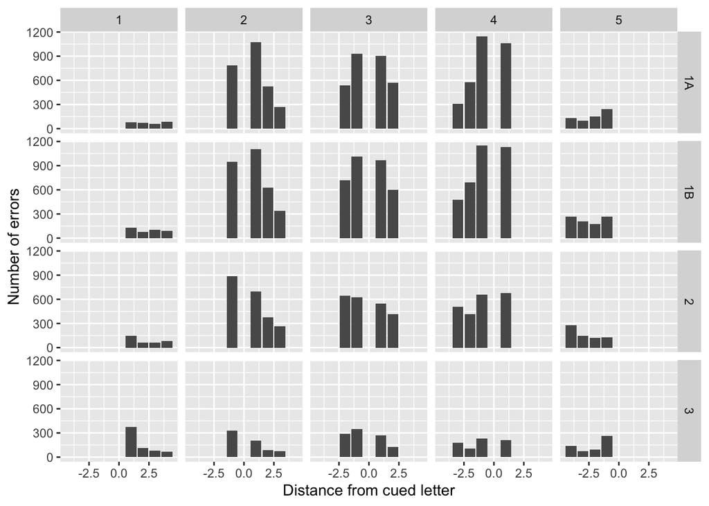

The columns are the cued letter, and the rows are the experiments. Naturally, we don’t have a lot of errors for the first and last positions, but there’s something interesting going on in experiment 3 for the first position where a lot of people reported the second character, whereas in the other experiments, it seems like the errors are drawn randomly from the rest of the string. For the middle positions, we see more errors in adjacent positions, with a progressive drop-off with increasing eccentricity from the cued letter.

Separated by experiment, cue time (pre or post) or type (ordinal vs underscore), fixed vs variable position, and position on screen (left, center, right):

### Experiment 1A

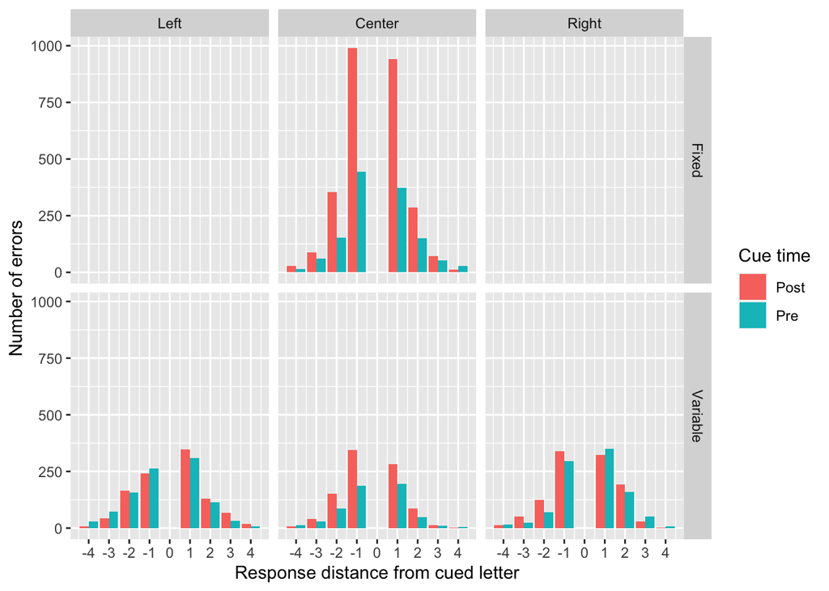

### Experiment 1B

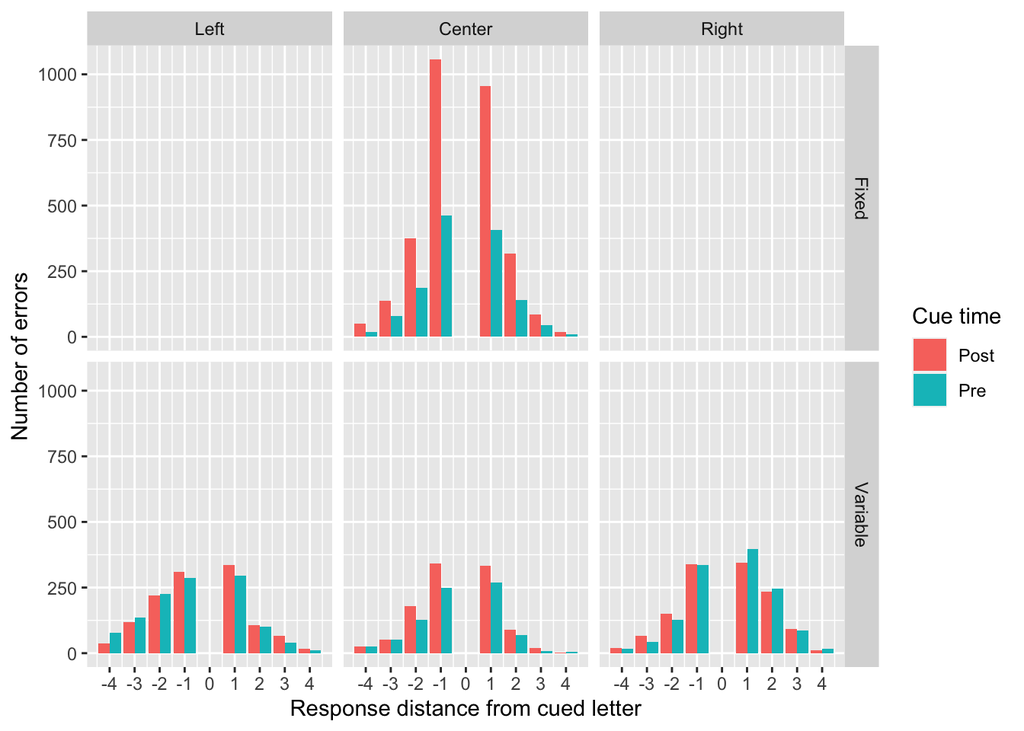

### Experiment 2

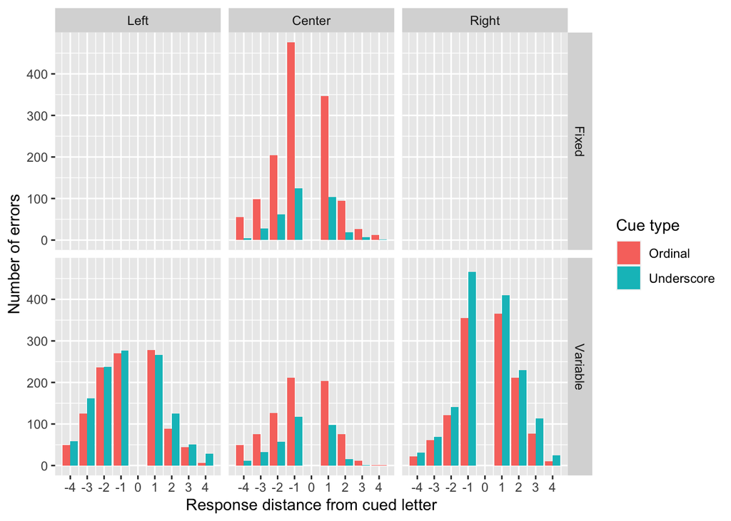

### Experiment 3

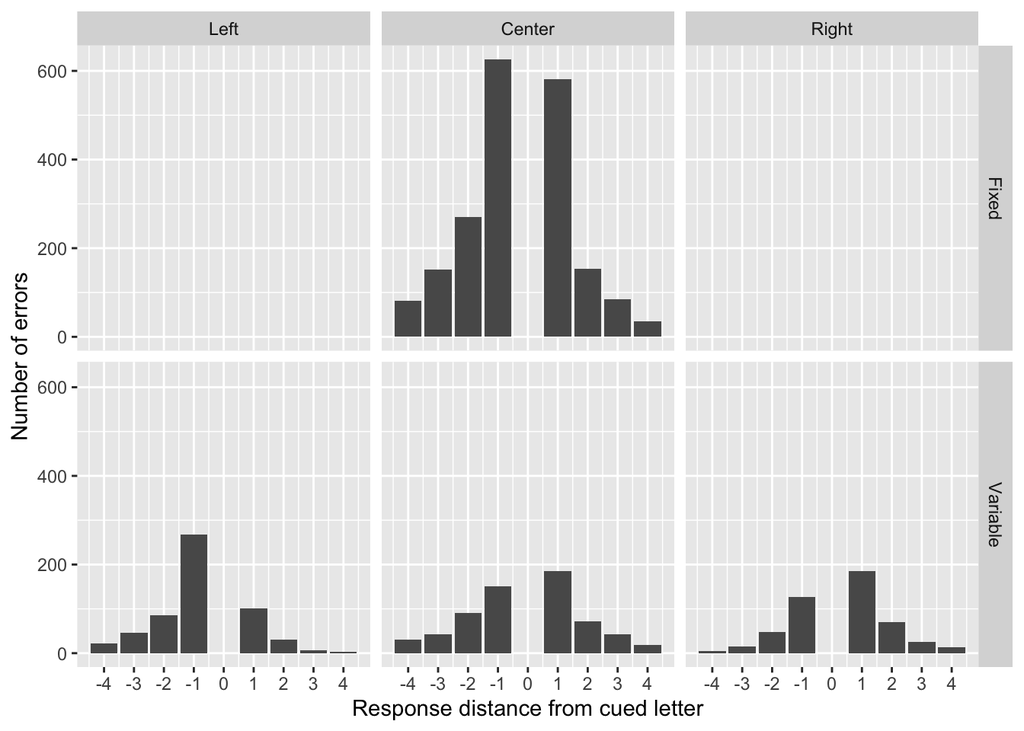

## Serial position functions

### Experiment 1

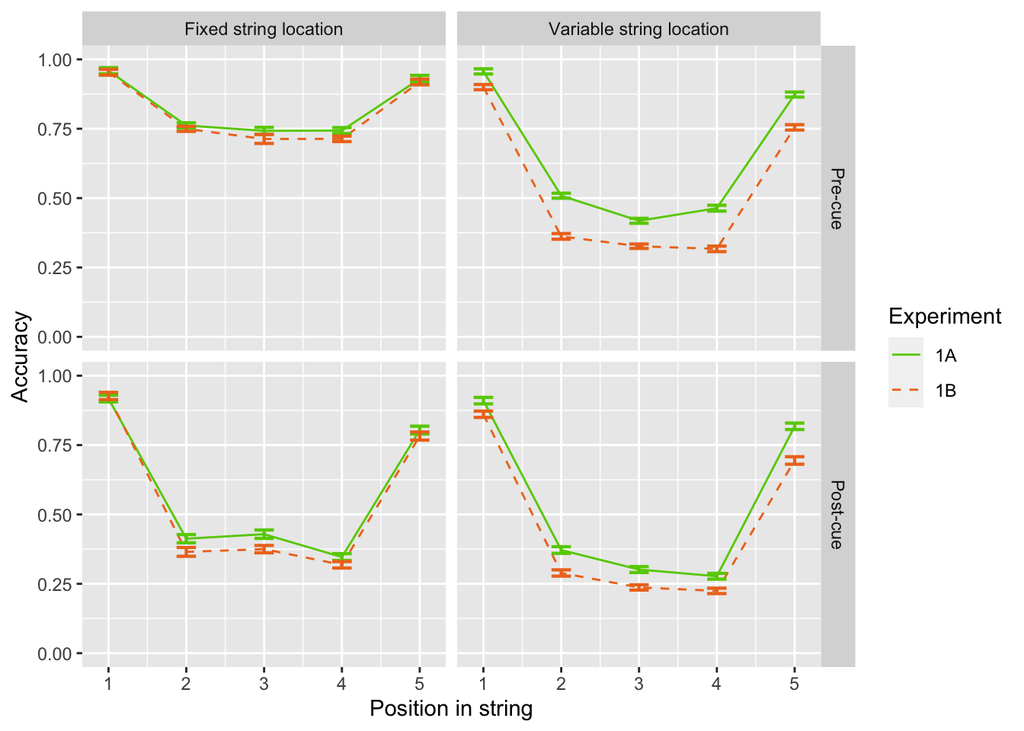

### Variable location trials (Exp 1)

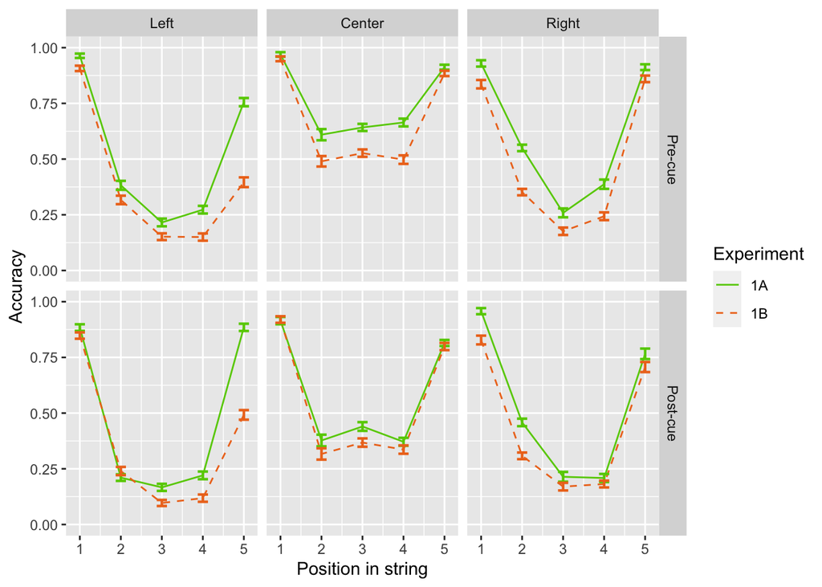

### Experiment 2

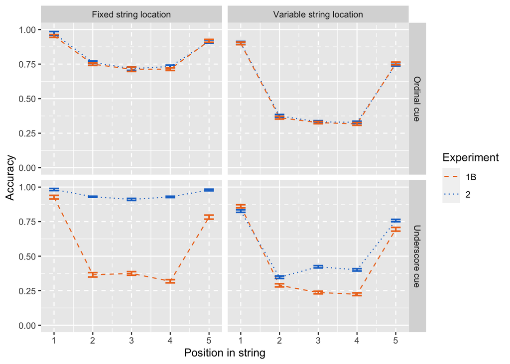

### Experiment 3

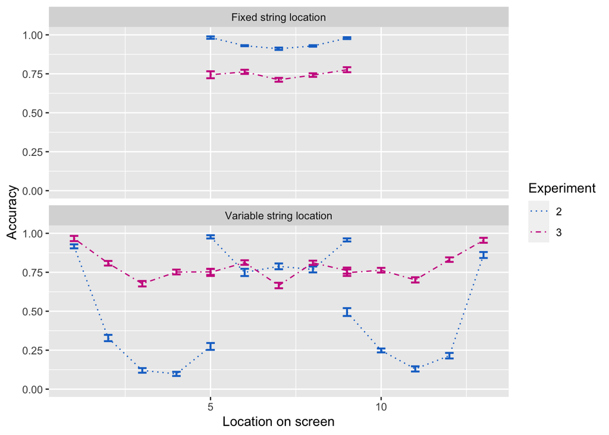

## Tables of data

Percent correct per participant and condition. `fix` corresponds to the Fixed location condition, `var` to variable. `Ord` for Ordinal, `Und` for Underscore.

### Experiment 1A

| Participant ID | fix Ord | fix Und | var Ord | var Und |
| --- | --- | --- | --- | --- |
| 173376 | 0.90 | 0.60 | 0.64 | 0.52 |
| 173377 | 0.70 | 0.63 | 0.57 | 0.55 |
| 173379 | 0.82 | 0.59 | 0.62 | 0.52 |
| 173385 | 0.92 | 0.55 | 0.64 | 0.41 |
| 173468 | 0.88 | 0.56 | 0.65 | 0.54 |
| 173531 | 0.94 | 0.67 | 0.67 | 0.63 |
| 173532 | 0.84 | 0.52 | 0.61 | 0.49 |
| 173533 | 0.83 | 0.50 | 0.59 | 0.47 |
| 173534 | 0.54 | 0.65 | 0.61 | 0.60 |
| 173535 | 0.88 | 0.56 | 0.64 | 0.60 |
| 173536 | 0.99 | 0.81 | 0.81 | 0.75 |
| 173537 | 0.62 | 0.51 | 0.60 | 0.50 |
| 173538 | 0.88 | 0.56 | 0.46 | 0.61 |
| 173539 | 0.97 | 0.74 | 0.79 | 0.63 |
| 173540 | 0.86 | 0.70 | 0.55 | 0.56 |
| 173541 | 0.60 | 0.63 | 0.56 | 0.53 |
| 173542 | 0.62 | 0.46 | 0.48 | 0.48 |
| 173543 | 0.78 | 0.59 | 0.62 | 0.51 |
| 173544 | 0.83 | 0.61 | 0.65 | 0.64 |
| 173548 | 0.69 | 0.74 | 0.67 | 0.53 |
| 173721 | 0.89 | 0.62 | 0.72 | 0.46 |
| 173723 | 0.92 | 0.52 | 0.70 | 0.55 |
| 173724 | 0.90 | 0.51 | 0.69 | 0.39 |
| 173725 | 0.92 | 0.73 | 0.62 | 0.61 |
| 173726 | 0.92 | 0.68 | 0.75 | 0.61 |
| 173727 | 0.87 | 0.70 | 0.69 | 0.70 |
| 173728 | 0.93 | 0.56 | 0.71 | 0.52 |
| 173730 | 0.46 | 0.67 | 0.67 | 0.47 |
| 173731 | 0.87 | 0.26 | 0.46 | 0.21 |
| 173732 | 0.92 | 0.50 | 0.61 | 0.42 |

[output cut: 69 more lines]

### Experiment 1B

| Participant ID | fix Ord | fix Und | var Ord | var Und |
| --- | --- | --- | --- | --- |
| 178465 | 0.79 | 0.72 | 0.60 | 0.62 |
| 178466 | 0.77 | 0.46 | 0.48 | 0.44 |
| 178467 | 0.82 | 0.33 | 0.51 | 0.30 |
| 178469 | 0.90 | 0.40 | 0.52 | 0.44 |
| 178470 | 0.55 | 0.48 | 0.39 | 0.26 |
| 178519 | 0.66 | 0.43 | 0.40 | 0.33 |
| 178520 | 0.92 | 0.60 | 0.62 | 0.56 |
| 178521 | 0.81 | 0.58 | 0.52 | 0.46 |
| 178524 | 0.74 | 0.63 | 0.50 | 0.55 |
| 178525 | 0.69 | 0.58 | 0.46 | 0.46 |
| 178526 | 0.85 | 0.52 | 0.57 | 0.48 |
| 178527 | 0.94 | 0.68 | 0.46 | 0.50 |
| 178528 | 0.72 | 0.70 | 0.56 | 0.59 |
| 178529 | 0.91 | 0.65 | 0.65 | 0.57 |
| 178531 | 0.94 | 0.88 | 0.74 | 0.66 |
| 178532 | 0.95 | 0.55 | 0.51 | 0.53 |
| 178533 | 0.86 | 0.56 | 0.58 | 0.44 |
| 178534 | 0.77 | 0.50 | 0.52 | 0.48 |
| 178535 | 0.96 | 0.78 | 0.76 | 0.70 |
| 178536 | 0.95 | 0.77 | 0.75 | 0.67 |
| 178537 | 0.72 | 0.53 | 0.50 | 0.50 |
| 178539 | 0.75 | 0.59 | 0.50 | 0.48 |
| 178540 | 0.91 | 0.34 | 0.39 | 0.23 |
| 178541 | 0.93 | 0.41 | 0.50 | 0.41 |
| 178542 | 0.83 | 0.32 | 0.53 | 0.29 |
| 178544 | 0.90 | 0.63 | 0.61 | 0.55 |
| 178545 | 0.98 | 0.73 | 0.63 | 0.58 |
| 178546 | 0.79 | 0.55 | 0.51 | 0.38 |
| 178548 | 0.82 | 0.45 | 0.60 | 0.44 |
| 178549 | 0.98 | 0.58 | 0.57 | 0.49 |

[output cut: 70 more lines]

### Experiment 2

| Participant ID | fix Ord | fix Und | var Ord | var Und |
| --- | --- | --- | --- | --- |
| 190478 | 0.83 | 1.00 | 0.53 | 0.64 |
| 190480 | 0.22 | 0.86 | 0.16 | 0.37 |
| 190482 | 0.37 | 0.65 | 0.25 | 0.40 |
| 190483 | 0.93 | 0.98 | 0.66 | 0.57 |
| 190484 | 0.98 | 1.00 | 0.56 | 0.57 |
| 190485 | 0.80 | 0.95 | 0.61 | 0.59 |
| 190488 | 0.85 | 1.00 | 0.23 | 0.47 |
| 190498 | 0.89 | 1.00 | 0.60 | 0.61 |
| 190505 | 0.79 | 1.00 | 0.13 | 0.30 |
| 190529 | 0.92 | 1.00 | 0.49 | 0.56 |
| 191098 | 0.91 | 1.00 | 0.71 | 0.60 |
| 191099 | 0.53 | 0.96 | 0.36 | 0.46 |
| 191101 | 0.97 | 1.00 | 0.73 | 0.66 |
| 191102 | 1.00 | 1.00 | 0.58 | 0.64 |
| 191103 | 0.61 | 0.71 | 0.52 | 0.39 |
| 191104 | 0.87 | 1.00 | 0.62 | 0.59 |
| 191105 | 0.86 | 0.99 | 0.48 | 0.59 |
| 191106 | 0.94 | 0.98 | 0.63 | 0.66 |
| 191107 | 0.90 | 0.99 | 0.67 | 0.58 |
| 191109 | 0.98 | 0.98 | 0.61 | 0.61 |
| 191115 | 0.62 | 0.72 | 0.57 | 0.59 |
| 191117 | 0.88 | 0.98 | 0.65 | 0.58 |
| 191118 | 0.88 | 1.00 | 0.62 | 0.55 |
| 191119 | 0.94 | 0.99 | 0.61 | 0.59 |
| 191120 | 0.87 | 0.96 | 0.59 | 0.54 |
| 191122 | 0.81 | 1.00 | 0.69 | 0.60 |
| 191124 | 0.78 | 0.99 | 0.50 | 0.63 |
| 191129 | 0.78 | 0.99 | 0.60 | 0.49 |
| 191130 | 0.66 | 0.98 | 0.37 | 0.45 |
| 191135 | 0.88 | 0.98 | 0.66 | 0.60 |

[output cut: 67 more lines]

### Experiment 3

| Participant ID | fix Und | var Und |
| --- | --- | --- |
| 191994 | 0.81 | 0.99 |
| 191997 | 0.80 | 0.87 |
| 191999 | 0.40 | 0.54 |
| 192001 | 0.99 | 0.99 |
| 192003 | 0.87 | 0.86 |
| 192004 | 0.51 | 0.67 |
| 192006 | 0.31 | 0.36 |
| 192007 | 0.51 | 0.78 |
| 192008 | 0.65 | 0.88 |
| 192009 | 0.74 | 0.67 |
| 192084 | 0.97 | 0.98 |
| 192085 | 1.00 | 0.96 |
| 192086 | 0.33 | 0.49 |
| 192087 | 0.73 | 0.88 |
| 192088 | 0.98 | 1.00 |
| 192089 | 0.83 | 0.86 |
| 192091 | 0.93 | 0.97 |
| 192092 | 0.95 | 0.94 |
| 192093 | 0.90 | 0.97 |
| 192094 | 0.84 | 0.83 |
| 192095 | 0.59 | 0.64 |
| 192097 | 0.72 | 0.81 |
| 192100 | 0.44 | 0.60 |
| 192101 | 0.64 | 0.81 |
| 192103 | 0.52 | 0.66 |
| 192104 | 0.32 | 0.47 |
| 192105 | 0.93 | 0.85 |
| 192106 | 0.44 | 0.41 |
| 192107 | 0.79 | 0.90 |
| 192108 | 1.00 | 0.99 |

[output cut: 69 more lines]